# Working Report_Black Friday

Brad Kim, Casey O’Malley, Qi Ding, Zoe Huang

# Part1: Pre-process

Let’s take a **quick overview** of the entire dataset

```r
summary(data)
```

```
##     User_ID            Product_ID     Gender        Age
##  Min.   :1000001   P00265242:  1858   F:132197   0-17 : 14707
##  1st Qu.:1001495   P00110742:  1591   M:405380   18-25: 97634
##  Median :1003031   P00025442:  1586              26-35:214690
##  Mean   :1002992   P00112142:  1539              36-45:107499
##  3rd Qu.:1004417   P00057642:  1430              46-50: 44526
##  Max.   :1006040   P00184942:  1424              51-55: 37618
##                    (Other)  :528149              55+  : 20903
##    Occupation     City_Category Stay_In_Current_City_Years
##  Min.   : 0.000   A:144638      0 : 72725
##  1st Qu.: 2.000   B:226493      1 :189192
##  Median : 7.000   C:166446      2 : 99459
##  Mean   : 8.083                 3 : 93312
##  3rd Qu.:14.000                 4+: 82889
##  Max.   :20.000
##
##  Marital_Status   Product_Category_1 Product_Category_2 Product_Category_3
##  Min.   :0.0000   Min.   : 1.000     Min.   : 2.00      Min.   : 3.0
##  1st Qu.:0.0000   1st Qu.: 1.000     1st Qu.: 5.00      1st Qu.: 9.0
##  Median :0.0000   Median : 5.000     Median : 9.00      Median :14.0
##  Mean   :0.4088   Mean   : 5.296     Mean   : 9.84      Mean   :12.7
##  3rd Qu.:1.0000   3rd Qu.: 8.000     3rd Qu.:15.00      3rd Qu.:16.0
##  Max.   :1.0000   Max.   :18.000     Max.   :18.00      Max.   :18.0
##                                      NA's   :166986     NA's   :373299
##     Purchase
##  Min.   :  185
##  1st Qu.: 5866
##  Median : 8062
##  Mean   : 9334
##  3rd Qu.:12073
##  Max.   :23961
##
```

```r
str(data)
```

```
## 'data.frame':    537577 obs. of  12 variables:
##  $ User_ID                   : int  1000001 1000001 1000001 1000001 1000002 1000003 1000004 1000004 1000004 1000005 ...
##  $ Product_ID                : Factor w/ 3623 levels "P00000142","P00000242",..: 671 2375 851 827 2733 1830 1744 3319 3597 2630 ...
##  $ Gender                    : Factor w/ 2 levels "F","M": 1 1 1 1 2 2 2 2 2 2 ...
##  $ Age                       : Factor w/ 7 levels "0-17","18-25",..: 1 1 1 1 7 3 5 5 5 3 ...
##  $ Occupation                : int  10 10 10 10 16 15 7 7 7 20 ...
##  $ City_Category             : Factor w/ 3 levels "A","B","C": 1 1 1 1 3 1 2 2 2 1 ...
##  $ Stay_In_Current_City_Years: Factor w/ 5 levels "0","1","2","3",..: 3 3 3 3 5 4 3 3 3 2 ...
##  $ Marital_Status            : int  0 0 0 0 0 0 1 1 1 1 ...
##  $ Product_Category_1        : int  3 1 12 12 8 1 1 1 1 8 ...
##  $ Product_Category_2        : int  NA 6 NA 14 NA 2 8 15 16 NA ...
##  $ Product_Category_3        : int  NA 14 NA NA NA NA 17 NA NA NA ...
##  $ Purchase                  : int  8370 15200 1422 1057 7969 15227 19215 15854 15686 7871 ...
```

```r
head(data)
```

```
##   User_ID Product_ID Gender   Age Occupation City_Category
## 1 1000001  P00069042      F  0-17         10             A
## 2 1000001  P00248942      F  0-17         10             A
## 3 1000001  P00087842      F  0-17         10             A
## 4 1000001  P00085442      F  0-17         10             A
## 5 1000002  P00285442      M   55+         16             C
## 6 1000003  P00193542      M 26-35         15             A
##   Stay_In_Current_City_Years Marital_Status Product_Category_1
## 1                          2              0                  3
## 2                          2              0                  1
## 3                          2              0                 12
## 4                          2              0                 12
## 5                         4+              0                  8
## 6                          3              0                  1
##   Product_Category_2 Product_Category_3 Purchase
## 1                 NA                 NA     8370
## 2                  6                 14    15200
## 3                 NA                 NA     1422
## 4                 14                 NA     1057
## 5                 NA                 NA     7969
## 6                  2                 NA    15227
```

**There are 12 different columns**: each represents a corresponding variable below :

```
- User_ID: Unique identifier of shopper.
- Product_ID: Unique identifier of product. (No key given)
- Gender: Sex of shopper.
- Age: Age of shopper split into bins.
- Occupation: Occupation of shopper. (No key given)
- City_Category: Residence location of shopper. (No key given)
- Stay_In_Current_City_Years: Number of years stay in current city.
- Marital_Status: Marital status of shopper. 0 is corresponds to the non-marriage people, 1 is corresponds to the marriage people.
- Product_Category_1: Product category of purchase.
- Product_Category_2: Product may belong to other category.
- Product_Category_3: Product may belong to other category.
- Purchase: Purchase amount in dollars.
```

**Change data type of variable**: Convert some of the features to factors (some ordinal and others nominal), for affinity analysis

```r
data$User_ID <- as.factor(data$User_ID)
data$Product_ID <- as.factor(data$Product_ID)
data$Gender <- as.factor(data$Gender)
data$Age <- ordered(data$Age, labels = c("0-17", "18-25", "26-35", "36-45", "46-50", "51-55", "55+"))
data$Occupation <- as.factor(data$Occupation)
data$City_Category <- ordered(data$City_Category)
data$Stay_In_Current_City_Years <- ordered(data$Stay_In_Current_City_Years)
data$Marital_Status <- as.factor(data$Marital_Status)

data$Product_Category_1 <- as.factor(data$Product_Category_1)
data$Product_Category_2 <- as.factor(data$Product_Category_2)
data$Product_Category_3 <- as.factor(data$Product_Category_3)
```

**Check missing value**

```r
num_var = names(data)[sapply(data,is.numeric)]
cat_var = names(data)[!sapply(data,is.numeric)]
mystat = apply(data[num_var],2,stat_function)
t(mystat)
```

```
##          var_type  length   miss_val mean               std
## Purchase "integer" "537577" "0"      "9333.85985263507" "4981.02213265648"
##          var                cv                  min   max     pct.75%
## Purchase "24810581.4860137" "0.533650838056056" "185" "23961" "12073"
##          pct.85% pct.90%   pct.95% pct.99% pct.100%
## Purchase "15619" "16337.4" "19342" "20668" "23961"
```

There are NA values for Product_Category_2 and Product_Category_3. NA for these two variables is likely to represent that the concerned person did not buy the products from these categories, so we decided to replace NA with zero.

```r
data[is.na(data)] = 0
```

Up to this point, we finished cleaning data procedure and already got the clean data for furture analysis. Below is the code that we will use in our next step for different analysis. **data** is now a cleaned dataset the same as the dataset we submitted in our project deliverable 1 named **cleaned_data**

# Part2 Explorative Data Analysis

### Part2-1: Overall analysis about customers

We divided our Explorative Data Analysis into two parts: First let’s explore the overall description about customers.

**How many unique customers are in the data**

```r
data %>%
  select(User_ID) %>%
  distinct() %>%
  summarise(`Unique Customer(s)` = n())
```

```
##   Unique Customer(s)
## 1               5891
```

There are 5891 Unique Customers are sitting in the Black Friday data. In other words, many customers have multiple transactions for different items.

**Count the number of transactions of each customer**

```r
customers_transaction = data %>%
                          group_by(User_ID) %>%
                          count(User_ID)
setorderv(customers_transaction,"n",-1)
customers_transaction
```

```
## # A tibble: 5,891 x 2
## # Groups:   User_ID [5,891]
##    User_ID     n
##  * <fct>   <int>
##  1 1001680  1025
##  2 1004277   978
##  3 1001941   898
##  4 1001181   861
##  5 1000889   822
##  6 1003618   766
##  7 1001150   752
##  8 1001015   739
##  9 1002909   717
## 10 1001449   714
## # … with 5,881 more rows
```

It looks like User_ID 1001680 shows up the most on our master ledger of shopper data. Since each individual row represents a different transaction, this user made **over 1000** total transactions!

**Calculate the total spending of each customer**

Now let’s do some investigation regarding store customers and their purchases. We will start by computing the total purchase amount by user ID

```r
customers_total_purchase_amount = data %>%
                                    group_by(User_ID) %>%
                                    summarise(Purchase_Amount = sum(Purchase))
setorderv(customers_total_purchase_amount,"Purchase_Amount",-1)
customers_total_purchase_amount
```

```
## # A tibble: 5,891 x 2
##    User_ID Purchase_Amount
##  * <fct>             <int>
##  1 1004277        10536783
##  2 1001680         8699232
##  3 1002909         7577505
##  4 1001941         6817493
##  5 1000424         6573609
##  6 1004448         6565878
##  7 1001015         6511302
##  8 1003391         6476786
##  9 1001181         6387899
## 10 1000549         6310604
## # … with 5,881 more rows
```

It looks like User_ID 1004277 spends the most on our master ledger of shopper data. This user spent *over $10536783* in total transactions during Black Friday!

We can join together these two tables above - the number of transactions of each customer dataset with our total customer purchases dataset - to see them combined.

```r
total_shoppers =  customers_transaction %>%
                    select(User_ID, n) %>%
                    left_join(customers_total_purchase_amount, Purchase_Amount, by = 'User_ID')

head(total_shoppers)
```

```
## # A tibble: 6 x 3
## # Groups:   User_ID [6]
##   User_ID     n Purchase_Amount
##   <fct>   <int>           <int>
## 1 1001680  1025         8699232
## 2 1004277   978        10536783
## 3 1001941   898         6817493
## 4 1001181   861         6387899
## 5 1000889   822         5499812
## 6 1003618   766         5961987
```

Now that we have joined these two tables together, we can see that although *User_ID 1001680* has the highest number of total transactions, *User_ID 1004277* has the highest Purchase_Amount as identified in our earlier analysis as well. From here, we can also compute the average Purchase_Amount for each user.

**Compute the average Purchase_Amout of each customer**

```r
total_shoppers = mutate(total_shoppers,
                  Average_Purchase_Amount = Purchase_Amount/n)
setorderv(total_shoppers,"Average_Purchase_Amount", -1)
head(total_shoppers)
```

```
## # A tibble: 6 x 4
## # Groups:   User_ID [6]
##   User_ID     n Purchase_Amount Average_Purchase_Amount
##   <fct>   <int>           <int>                   <dbl>
## 1 1005069    16          308454                  19278.
## 2 1003902    93         1746284                  18777.
## 3 1005999    18          330227                  18346.
## 4 1001349    23          417743                  18163.
## 5 1000101    65         1138239                  17511.
## 6 1003461    20          350174                  17509.
```

It looks like that *User_ID 1005069* has the highest Average_Purchase_Amount and a total Purchase_Amount of 308454. *User_ID 1003902* is right behind *User_ID 1005069* in Average_Purchase_Amount, but has a much higher total Purchase_Amount of 1746284.

### Part2-2: Detailed analysis about customers based on each variable

After taking a look at the overall description about customers, we will analyze sales by demographic analysis of customers eg city, age, gender, and such. The goal of this process is to give more information about our data so that the marketing team prepares to intensify the efficiency based on the data and information we will provide. Since there are several features provided, which enables us to ask interesting questions about customer-behaviour during Black friday, besides the analysis below, we also created a separate shiny reporting engine so that user can compare the result of each variable more easily.

### Gender

To begin our exploration, let’s examine the gender of shoppers at this store.

Since each row represents an individual transaction, we must first group the data by User_ID to remove duplicates.

```r
gender_data = data %>%
  select(User_ID, Gender) %>%
  group_by(Gender) %>%
  distinct() %>%
  summarize(Count = n())

gender_data
```

```
## # A tibble: 2 x 2
##   Gender Count
##   <fct>  <int>
## 1 F       1666
## 2 M       4225
```

Now that we have the data table necessary to see each User_IDs corresponding gender and their total counts for reference, let’s plot the distribution of gender across our dataset.

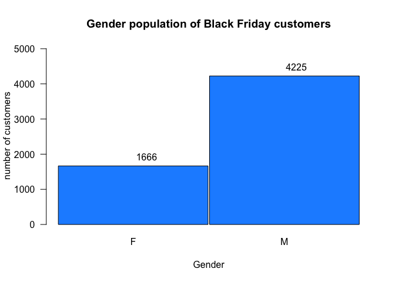

```r
# Visualize the Gender population
barplot(height = gender_data$Count, space=0.01, las = 1, main = "Gender population of Black Friday customers", ylab = "number of customers", xlab = "Gender", ylim = c(0, 1.2*max(gender_data$Count, na.rm = TRUE)), col = "dodgerblue", names.arg = gender_data$Gender)

space_val = 0
text(x = -0.4 + 1:length(gender_data$Gender) * (1+space_val), y = gender_data$Count, labels = gender_data$Count, pos = 3)
```

As we can see, there are quite a few more males than females shopping at our store on Black Friday. But it could also mean less number of females paid for the products and may be their spouse paid for them.

This gender split metric is helpful to retailers because some might want to modify their store layout, product selection, and other variables differently depending on the gender proportion of their shoppers, which displays a difference in the value derived from shopping and its relationship to gender.

To investigate further, let’s compute the total number of transactions of each person, the total spending of each person, the average spending amount of each transaction as they relate to Gender. For easy interpretation and traceback we will create separate tables and then go through one by one.

**The total number of transactions of each person**

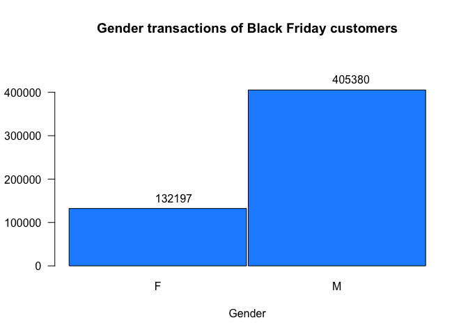

```r
gender_transaction = data %>%
  select(User_ID, Gender) %>%
  group_by(Gender) %>%
  summarize(Count = n())

# Visualize the Gender transaction
barplot(height = gender_transaction$Count, space=0.01, las = 1, main = "Gender transactions of Black Friday customers", xlab = "Gender", ylim = c(0, 1.2*max(gender_transaction$Count, na.rm = TRUE)), col = "dodgerblue", names.arg  = gender_transaction$Gender)

space_val = 0
text(x = -0.4 + 1:length(gender_transaction$Gender) * (1+space_val), y = gender_transaction$Count, labels = gender_transaction$Count, pos = 3)
```

**The total spending of each person**

```r
avg_gender_spending_per_person = data %>%
  select(User_ID, Gender, Purchase) %>%
  group_by(Gender) %>%
  summarize(Total_purchase = sum(as.numeric(Purchase))) %>%
  full_join(gender_data, by = "Gender") %>%
  group_by(Gender) %>%
  summarize(Average = Total_purchase/Count)

avg_gender_spending_per_person
```

```
## # A tibble: 2 x 2
##   Gender Average
##   <fct>    <dbl>
## 1 F      699054.
## 2 M      911963.
```

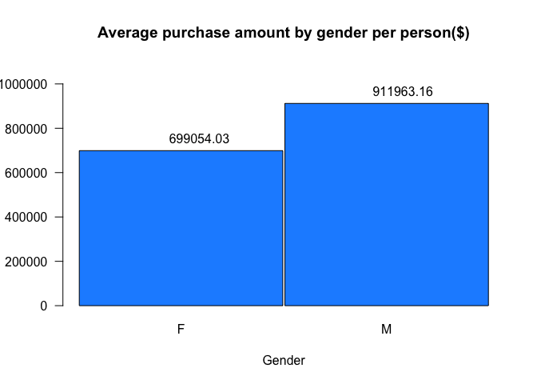

```r
# Visualize the avg_gender_spending_per_person
barplot(height = avg_gender_spending_per_person$Average, space=0.01, las = 1, main = "Average purchase amount by gender per person($)", xlab = "Gender", ylim = c(0, 1.2*max(avg_gender_spending_per_person$Average, na.rm = TRUE)), col = "dodgerblue", names.arg  = avg_gender_spending_per_person$Gender)

space_val = 0
text(x = -0.4 + 1:length(avg_gender_spending_per_person$Gender) * (1+space_val), y = avg_gender_spending_per_person$Average, labels = round(avg_gender_spending_per_person$Average,2), pos = 3)
```

**The average spending amount of each transaction**

```r
avg_gender_spending_per_transaction = data %>%
  select(User_ID, Gender, Purchase) %>%
  group_by(Gender) %>%
  summarize(Total_purchase = sum(as.numeric(Purchase)),
            Count = n(),
            Average = Total_purchase/Count)

avg_gender_spending_per_transaction
```

```
## # A tibble: 2 x 4
##   Gender Total_purchase  Count Average
##   <fct>           <dbl>  <int>   <dbl>
## 1 F          1164624021 132197   8810.
## 2 M          3853044357 405380   9505.
```

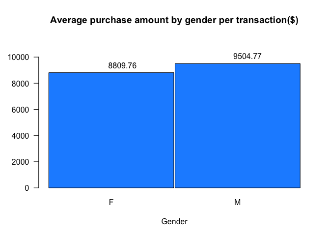

```r
# Visualize the avg_gender_spending_per_transaction
barplot(height = avg_gender_spending_per_transaction$Average, space=0.01, las = 1, main = "Average purchase amount by gender per transaction($)", xlab = "Gender", ylim = c(0, 1.2*max(avg_gender_spending_per_transaction$Average, na.rm = TRUE)), col = "dodgerblue",names.arg  = avg_gender_spending_per_transaction$Gender)

space_val = 0
text(x = -0.4 + 1:length(avg_gender_spending_per_transaction$Gender) * (1+space_val), y = avg_gender_spending_per_transaction$Average, labels = round(avg_gender_spending_per_transaction$Average,2), pos = 3)
```

**Interesting fact 1**: female shoppers make less transactions than males at this specific store, they spend 695.0103644 less on each transaction than male shoppers, and females on average are still spending about 212909.1272064 less than males for each person.

```r
top_item = data %>%
  count(Product_ID, sort = T)

top_5 = top_item[1:5,]
datatable(top_5)
```

|  | Product_ID | n |
| --- | --- | --- |
| 1 | P00265242 | 1858 |
| 2 | P00110742 | 1591 |
| 3 | P00025442 | 1586 |
| 4 | P00112142 | 1539 |
| 5 | P00057642 | 1430 |

Top 5 items : P00265242, P00110742, P00025442, P00112142, P00057642 Now, we track down by Gender

```r
data[data$Product_ID %in% top_5$Product_ID,] %>%
  select(User_ID, Product_ID, Gender, Purchase) %>%
  group_by(Product_ID, Gender) %>%
  summarize(Total_purchase = sum(as.numeric(Purchase)),
            Count = n()) %>%
  mutate(Average = Total_purchase/Count)
```

```
## # A tibble: 10 x 5
## # Groups:   Product_ID [5]
##    Product_ID Gender Total_purchase Count Average
##    <fct>      <fct>           <dbl> <int>   <dbl>
##  1 P00025442  F             5763524   341  16902.
##  2 P00025442  M            21768902  1245  17485.
##  3 P00057642  F             3773330   256  14740.
##  4 P00057642  M            18720360  1174  15946.
##  5 P00110742  F             5632357   357  15777.
##  6 P00110742  M            20750212  1234  16815.
##  7 P00112142  F             4901047   332  14762.
##  8 P00112142  M            18981577  1207  15726.
##  9 P00265242  F             3761043   505   7448.
## 10 P00265242  M            10222282  1353   7555.
```

**Interesting Fact 2**: even though people are purchasing the same product, they are paying different prices. Clearly, Females are paying less than male shoppers for all Top5 items. This could be explained by varied Black Friday promotions, discounts, or coupon codes.

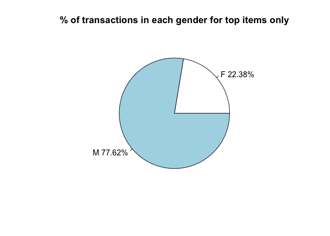

```r
gender_transaction_Top_item = data[data$Product_ID %in% top_5$Product_ID,] %>%
  select(User_ID, Gender) %>%
  group_by(Gender) %>%
  summarize(Count = n())

# Visualize the Gender transaction for top items only
pie(gender_transaction_Top_item$Count, labels = paste(paste(gender_transaction_Top_item$Gender,round(gender_transaction_Top_item$Count/sum(gender_transaction_Top_item$Count)*100,2)),"%",sep = ""), main="% of transactions in each gender for top items only")
```

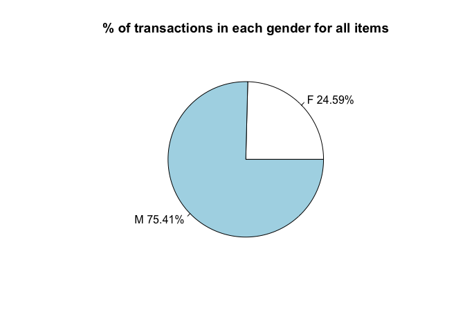

```r
# Visualize the overall Gender transaction
pie(gender_transaction$Count, labels = paste(paste(gender_transaction$Gender,round(gender_transaction$Count/sum(gender_transaction$Count)*100,2)),"%",sep = ""), main="% of transactions in each gender for all items")
```

We can see that within the overall observation set, both purchasers of the best seller and purchasers of all products are roughly ~25% female and ~75% male. A slight difference does exist but it seems like we can generally conclude that our best seller does not cater to a specific gender.

Knowing that we the store is not a specific gender orientated, we decided to take a look at other varibles such as age, cities, and occupation.

### AGE

Now, let’s examine the age of shoppers at this store.

Also, since each row represents an individual transaction, we must first group the data by User_ID to remove duplicates.

```r
age_data = data %>%
  select(User_ID, Age) %>%
  group_by(Age) %>%
  distinct() %>%
  summarize(Count = n())

age_data
```

```
## # A tibble: 7 x 2
##   Age   Count
##   <ord> <int>
## 1 0-17    218
## 2 18-25  1069
## 3 26-35  2053
## 4 36-45  1167
## 5 46-50   531
## 6 51-55   481
## 7 55+     372
```

Now that we have the data table necessary to see each User_IDs corresponding age and their total counts for reference, let’s plot the distribution of age across our dataset.

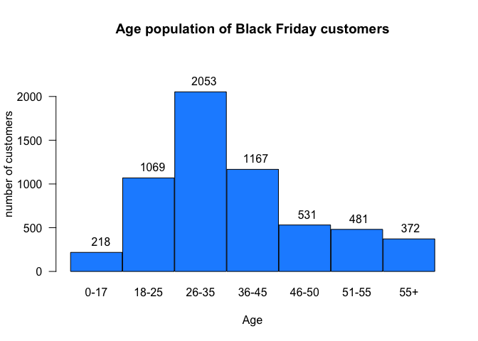

```r
# Visualize the Age population
barplot(height = age_data$Count, space=0.01, las = 1, main = "Age population of Black Friday customers", ylab = "number of customers", xlab = "Age", ylim = c(0, 1.2*max(age_data$Count, na.rm = TRUE)), col = "dodgerblue", names.arg = age_data$Age)

space_val = 0
text(x = -0.4 + 1:length(age_data$Age) * (1+space_val), y = age_data$Count, labels = age_data$Count, pos = 3)
```

Like what we did in last section, to investigate further, let’s compute the total number of transactions of each person, the total spending of each person, the average spending amount of each transaction as they relate to Age. For easy interpretation and traceback we will create separate tables and then go through one by one.

**The total number of transactions of each person**

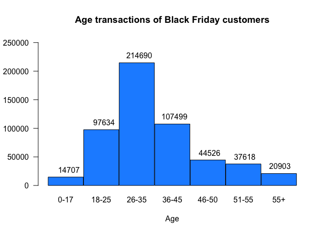

```r
age_transaction = data %>%
  select(User_ID, Age) %>%
  group_by(Age) %>%
  summarize(Count = n())

# Visualize the Age transaction
barplot(height = age_transaction$Count, space=0.01, las = 1, main = "Age transactions of Black Friday customers", xlab = "Age", ylim = c(0, 1.2*max(age_transaction$Count, na.rm = TRUE)), col = "dodgerblue", names.arg  = age_transaction$Age)

space_val = 0
text(x = -0.4 + 1:length(age_transaction$Age) * (1+space_val), y = age_transaction$Count, labels = age_transaction$Count, pos = 3)
```

It’s quite apparent that the largest age group amongst the customers is 26-35, in terms of either number of customers or number of transactions. But does this mean that the amount of money spent amongst the age groups is different significantly? Let’s see…

**The total spending of each person**

```r
avg_age_spending_per_person = data %>%
  select(User_ID, Age, Purchase) %>%
  group_by(Age) %>%
  summarize(Total_purchase = sum(as.numeric(Purchase))) %>%
  full_join(age_data, by = "Age") %>%
  group_by(Age) %>%
  summarize(Average = Total_purchase/Count)

avg_age_spending_per_person
```

```
## # A tibble: 7 x 2
##   Age   Average
##   <ord>   <dbl>
## 1 0-17  608528.
## 2 18-25 843470.
## 3 26-35 974062.
## 4 36-45 866024.
## 5 46-50 778565.
## 6 51-55 752408.
## 7 55+   531223.
```

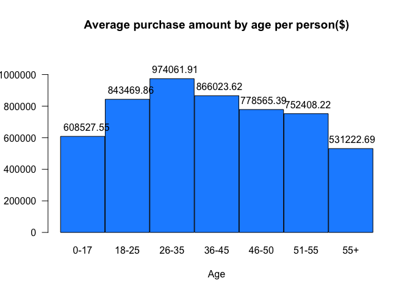

```r
# Visualize the avg_age_spending_per_person
barplot(height = avg_age_spending_per_person$Average, space=0.01, las = 1, main = "Average purchase amount by age per person($)", xlab = "Age", ylim = c(0, 1.2*max(avg_age_spending_per_person$Average, na.rm = TRUE)), col = "dodgerblue", names.arg  = avg_age_spending_per_person$Age)

space_val = 0
text(x = -0.4 + 1:length(avg_age_spending_per_person$Age) * (1+space_val), y = avg_age_spending_per_person$Average, labels = round(avg_age_spending_per_person$Average,2), pos = 3)
```

**Interesting fact 4**: It seems that this particular brand is loved by young and mid people (18-25, 26-35, and 36-45). Obviously, we can consider that the target age group of our stores is the age group of 26-35 years, we have achieved sales of more than 3 billion in the age group of 26-45 years.

**The average spending amount of each transaction**

```r
avg_age_spending_per_transaction = data %>%
  select(User_ID, Age, Purchase) %>%
  group_by(Age) %>%
  summarize(Total_purchase = sum(as.numeric(Purchase)),
            Count = n(),
            Average = Total_purchase/Count)

avg_age_spending_per_transaction
```

```
## # A tibble: 7 x 4
##   Age   Total_purchase  Count Average
##   <ord>          <dbl>  <int>   <dbl>
## 1 0-17       132659006  14707   9020.
## 2 18-25      901669280  97634   9235.
## 3 26-35     1999749106 214690   9315.
## 4 36-45     1010649565 107499   9401.
## 5 46-50      413418223  44526   9285.
## 6 51-55      361908356  37618   9621.
## 7 55+        197614842  20903   9454.
```

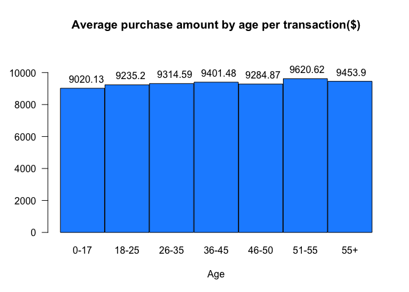

```r
# Visualize the avg_age_spending_per_transaction
barplot(height = avg_age_spending_per_transaction$Average, space=0.01, las = 1, main = "Average purchase amount by age per transaction($)", xlab = "Age", ylim = c(0, 1.2*max(avg_age_spending_per_transaction$Average, na.rm = TRUE)), col = "dodgerblue",names.arg  = avg_age_spending_per_transaction$Age)

space_val = 0
text(x = -0.4 + 1:length(avg_age_spending_per_transaction$Age) * (1+space_val), y = avg_age_spending_per_transaction$Average, labels = round(avg_age_spending_per_transaction$Average,2), pos = 3)
```

Our data clearly shows that the amount of money made from each age group correlates proportionally with the number of customers within the age groups. However, when it comes to the average spending amount of each transaction, the difference is not that obvious. This can be valuable information for the store, as it might want to add more products geared towards this age group in the future, or perhaps work on marketing different items to increase a broader diversity in the age groups of their customers.

Now, we track down the top 5 products by Age.

```r
data[data$Product_ID %in% top_5$Product_ID,] %>%
  select(User_ID, Product_ID, Age, Purchase) %>%
  group_by(Product_ID, Age) %>%
  summarize(Total_purchase = sum(as.numeric(Purchase)),
            Count = n()) %>%
  mutate(Average = Total_purchase/Count)
```

```
## # A tibble: 35 x 5
## # Groups:   Product_ID [5]
##    Product_ID Age   Total_purchase Count Average
##    <fct>      <ord>          <dbl> <int>   <dbl>
##  1 P00025442  0-17          852540    52  16395
##  2 P00025442  18-25        4884642   282  17321.
##  3 P00025442  26-35       10594786   595  17806.
##  4 P00025442  36-45        5917938   348  17006.
##  5 P00025442  46-50        2098048   122  17197.
##  6 P00025442  51-55        2041357   117  17447.
##  7 P00025442  55+          1143115    70  16330.
##  8 P00057642  0-17          552468    33  16741.
##  9 P00057642  18-25        4446409   288  15439.
## 10 P00057642  26-35        9110947   581  15681.
## # … with 25 more rows
```

**Interesting fact 5**: The trend that each group pays for different price for same products happens in Age group as well. But, it is not as significant as it is in Gender. Still, what’s interesting is that an age group who pays the least for a specific product now pays the most for another products. This could be also explained by varied Black Friday discounts, or coupon codes; yet, precisely, this could be caused by promotion for targeting customer marketing strategy.

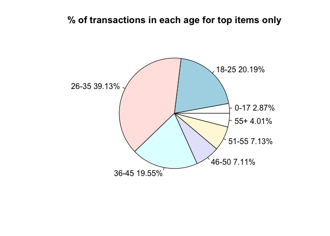

```r
age_transaction_Top_item = data[data$Product_ID %in% top_5$Product_ID,] %>%
  select(User_ID, Age) %>%
  group_by(Age) %>%
  summarize(Count = n())

# Visualize the Age transaction for top items only
pie(age_transaction_Top_item$Count, labels = paste(paste(age_transaction_Top_item$Age,round(age_transaction_Top_item$Count/sum(age_transaction_Top_item$Count)*100,2)),"%",sep = ""), main="% of transactions in each age for top items only")
```

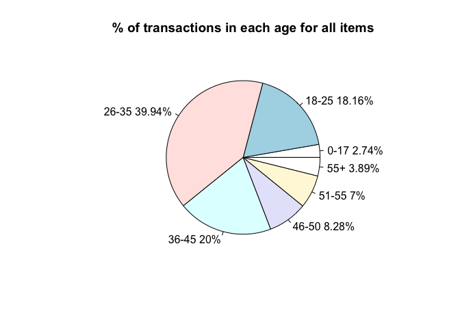

```r
# Visualize the overall Age transaction
pie(age_transaction$Count, labels = paste(paste(age_transaction$Age,round(age_transaction$Count/sum(age_transaction$Count)*100,2)),"%",sep = ""), main="% of transactions in each age for all items")
```

It seems that these top products are loved by young and mid people (18-25, 26-35, and 36-45). Compared with the overall distribution pie chat, there is no any specific age category that purchased the best selling product more than other shoppers.

### CITY_CATEGORY

Next, Let’s see how each city purchased on blackfriday.

Firstly, we must group the data by User_ID to remove duplicates.

```r
City_Category_data = data %>%
  select(User_ID, City_Category) %>%
  group_by(City_Category) %>%
  distinct() %>%
  summarize(Count = n())

City_Category_data
```

```
## # A tibble: 3 x 2
##   City_Category Count
##   <ord>         <int>
## 1 A              1045
## 2 B              1707
## 3 C              3139
```

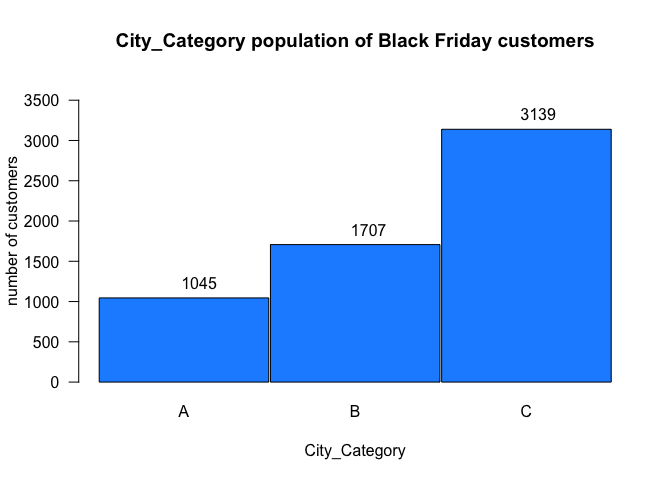

```r
# Visualize the City_Category population
barplot(height = City_Category_data$Count, space=0.01, las = 1, main = "City_Category population of Black Friday customers", ylab = "number of customers", xlab = "City_Category", ylim = c(0, 1.2*max(City_Category_data$Count, na.rm = TRUE)), col = "dodgerblue", names.arg = City_Category_data$City_Category)

space_val = 0
text(x = -0.4 + 1:length(City_Category_data$City_Category) * (1+space_val), y = City_Category_data$Count, labels = City_Category_data$Count, pos = 3)
```

It is obvious that City category C has heights no. of users followed by B, followed by A.

To investigate further, let’s compute the total number of transactions of each person, the total spending of each person, the average spending amount of each transaction as they relate to city category For easy interpretation and traceback we will also create separate tables and then explore one by one.

**The total number of transactions of each person**

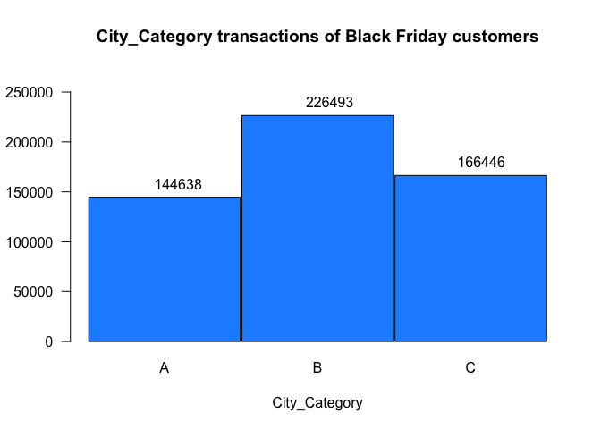

```r
City_Category_transaction = data %>%
  select(User_ID, City_Category) %>%
  group_by(City_Category) %>%
  summarize(Count = n())

# Visualize the City_Category transaction
barplot(height = City_Category_transaction$Count, space=0.01, las = 1, main = "City_Category transactions of Black Friday customers", xlab = "City_Category", ylim = c(0, 1.2*max(City_Category_transaction$Count, na.rm = TRUE)), col = "dodgerblue", names.arg  = City_Category_transaction$City_Category)

space_val = 0
text(x = -0.4 + 1:length(City_Category_transaction$City_Category) * (1+space_val), y = City_Category_transaction$Count, labels = City_Category_transaction$Count, pos = 3)
```

Regardless of population of each city, City B has the most number of transaction. Now, we can compute the total purchase amount of each person by City to see the which city’s customers spent the most at our store.

**The total spending of each person**

```r
avg_City_Category_spending_per_person = data %>%
  select(User_ID, City_Category, Purchase) %>%
  group_by(City_Category) %>%
  summarize(Total_purchase = sum(as.numeric(Purchase))) %>%
  full_join(City_Category_data, by = "City_Category") %>%
  group_by(City_Category) %>%
  summarize(Average = Total_purchase/Count)

avg_City_Category_spending_per_person
```

```
## # A tibble: 3 x 2
##   City_Category  Average
##   <ord>            <dbl>
## 1 A             1239874.
## 2 B             1220522.
## 3 C              522003.
```

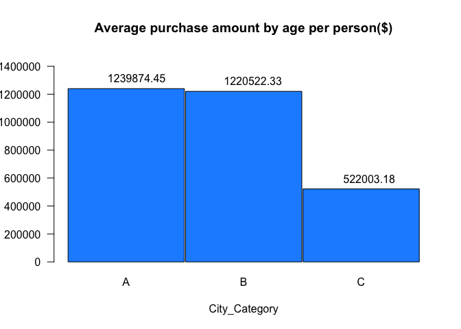

```r
# Visualize the avg_City_Category_spending_per_person
barplot(height = avg_City_Category_spending_per_person$Average, space=0.01, las = 1, main = "Average purchase amount by age per person($)", xlab = "City_Category", ylim = c(0, 1.2*max(avg_City_Category_spending_per_person$Average, na.rm = TRUE)), col = "dodgerblue", names.arg  = avg_City_Category_spending_per_person$City_Category)

space_val = 0
text(x = -0.4 + 1:length(avg_City_Category_spending_per_person$City_Category) * (1+space_val), y = avg_City_Category_spending_per_person$Average, labels = round(avg_City_Category_spending_per_person$Average,2), pos = 3)
```

**The average spending amount of each transaction**

```r
avg_City_Category_spending_per_transaction = data %>%
  select(User_ID, City_Category, Purchase) %>%
  group_by(City_Category) %>%
  summarize(Total_purchase = sum(as.numeric(Purchase)),
            Count = n(),
            Average = Total_purchase/Count)

avg_City_Category_spending_per_transaction
```

```
## # A tibble: 3 x 4
##   City_Category Total_purchase  Count Average
##   <ord>                  <dbl>  <int>   <dbl>
## 1 A                 1295668797 144638   8958.
## 2 B                 2083431612 226493   9199.
## 3 C                 1638567969 166446   9844.
```

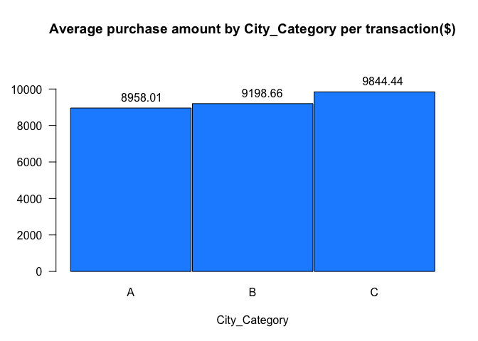

```r
# Visualize the avg_City_Category_spending_per_transaction
barplot(height = avg_City_Category_spending_per_transaction$Average, space=0.01, las = 1, main = "Average purchase amount by City_Category per transaction($)", xlab = "City_Category", ylim = c(0, 1.2*max(avg_City_Category_spending_per_transaction$Average, na.rm = TRUE)), col = "dodgerblue",names.arg  = avg_City_Category_spending_per_transaction$City_Category)

space_val = 0
text(x = -0.4 + 1:length(avg_City_Category_spending_per_transaction$City_Category) * (1+space_val), y = avg_City_Category_spending_per_transaction$Average, labels = round(avg_City_Category_spending_per_transaction$Average,2), pos = 3)
```

**Interesting fact 7**: One inference we can make from these charts is that customers from City B are simply making more purchases than residence of City A + City C, and not necessarily buying more expensive products. It is safe to make that claim due to the fact that the City B has the most Purcahse_Count by far diff from the others, but its purchasing power and Amount_per Transaction is similar to that of City A and even lower than City C.

Now, let’s examine the distribution of our best selling product within each City_Category.

```r
data[data$Product_ID %in% top_5$Product_ID,] %>%
  select(User_ID, Product_ID, City_Category, Purchase) %>%
  group_by(Product_ID, City_Category) %>%
  summarize(Total_purchase = sum(as.numeric(Purchase)),
            Count = n()) %>%
  mutate(Average = Total_purchase/Count)
```

```
## # A tibble: 15 x 5
## # Groups:   Product_ID [5]
##    Product_ID City_Category Total_purchase Count Average
##    <fct>      <ord>                  <dbl> <int>   <dbl>
##  1 P00025442  A                    5386234   317  16991.
##  2 P00025442  B                    9667058   550  17576.
##  3 P00025442  C                   12479134   719  17356.
##  4 P00057642  A                    4700520   307  15311.
##  5 P00057642  B                    7901887   500  15804.
##  6 P00057642  C                    9891283   623  15877.
##  7 P00110742  A                    5311364   322  16495.
##  8 P00110742  B                    9844481   581  16944.
##  9 P00110742  C                   11226724   688  16318.
## 10 P00112142  A                    4588223   303  15143.
## 11 P00112142  B                    8241958   530  15551.
## 12 P00112142  C                   11052443   706  15655.
## 13 P00265242  A                    2996071   396   7566.
## 14 P00265242  B                    4734396   626   7563.
## 15 P00265242  C                    6252858   836   7479.
```

**Interesting fact 8**: like what we have discussed before, even though people are purchasing the same product, they are paying different prices. Clearly, people in City A are paying less than those from the other two cities for most Top5 items. This could be explained by varied prices in different aging considering different living cost level.

Below two charts depicting the distribution of city categories within our “best seller” category as well as for all the items will show us if there is a specific city category that purchased the best selling product more than other shoppers..

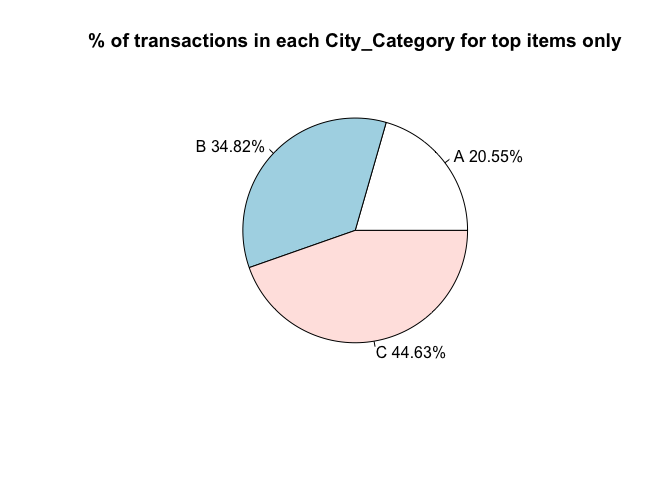

```r
City_Category_transaction_Top_item = data[data$Product_ID %in% top_5$Product_ID,] %>%
  select(User_ID, City_Category) %>%
  group_by(City_Category) %>%
  summarize(Count = n())

# Visualize the City_Category transaction for top items only
pie(City_Category_transaction_Top_item$Count, labels = paste(paste(City_Category_transaction_Top_item$City_Category,round(City_Category_transaction_Top_item$Count/sum(City_Category_transaction_Top_item$Count)*100,2)),"%",sep = ""), main="% of transactions in each City_Category for top items only")
```

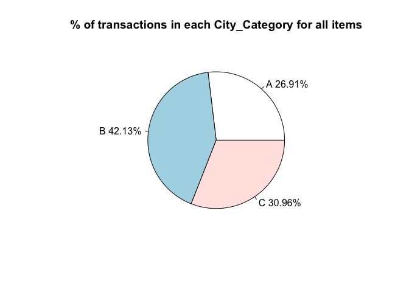

```r
# Visualize the overall City_Category transaction
pie(City_Category_transaction$Count, labels = paste(paste(City_Category_transaction$City_Category,round(City_Category_transaction$Count/sum(City_Category_transaction$Count)*100,2)),"%",sep = ""), main="% of transactions in each City_Category for all items")
```

**Interesting fact 8**: It seems that these top products are loved by people from city C. Also compared with the overall distribution pie chat, people from city C purchased the best selling product more than other shoppers.

### OCCUPATION

Next, let’s examine people do different kinds of jobs would have different purchasing behaviour, focusing on if the top items are targeting to people from specific occupations.

Firstly, we must group the data by User_ID to remove duplicates.

```r
Occupation_data = data %>%
  select(User_ID, Occupation) %>%
  group_by(Occupation) %>%
  distinct() %>%
  summarize(Count = n())

Occupation_data
```

```
## # A tibble: 21 x 2
##    Occupation Count
##    <fct>      <int>
##  1 0            688
##  2 1            517
##  3 2            256
##  4 3            170
##  5 4            740
##  6 5            111
##  7 6            228
##  8 7            669
##  9 8             17
## 10 9             88
## # … with 11 more rows
```

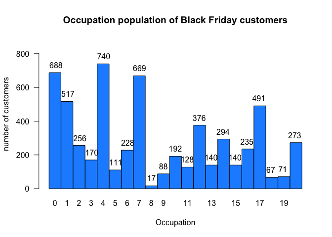

```r
# Visualize the City_Category population
barplot(height = Occupation_data$Count, space=0.01, las = 1, main = "Occupation population of Black Friday customers", ylab = "number of customers", xlab = "Occupation", ylim = c(0, 1.2*max(Occupation_data$Count, na.rm = TRUE)), col = "dodgerblue", names.arg = Occupation_data$Occupation)

space_val = 0
text(x = -0.4 + 1:length(Occupation_data$Occupation) * (1+space_val), y = Occupation_data$Count, labels = Occupation_data$Count, pos = 3)
```

**The total number of transactions of each person**

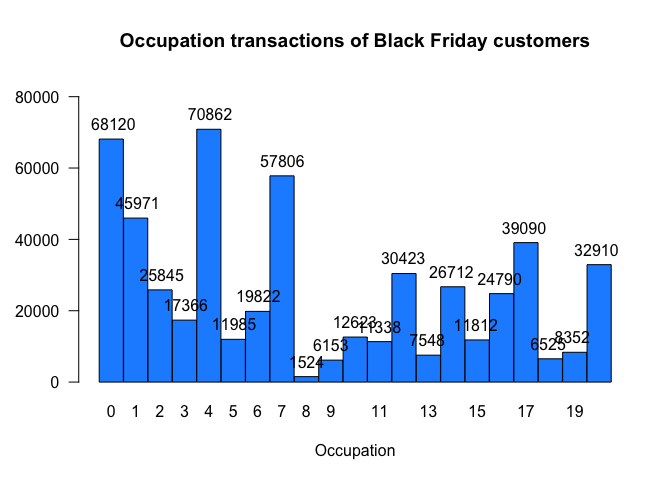

```r
Occupation_transaction = data %>%
  select(User_ID, Occupation) %>%
  group_by(Occupation) %>%
  summarize(Count = n())

# Visualize the Occupation transaction
barplot(height = Occupation_transaction$Count, space=0.01, las = 1, main = "Occupation transactions of Black Friday customers", xlab = "Occupation", ylim = c(0, 1.2*max(Occupation_transaction$Count, na.rm = TRUE)), col = "dodgerblue", names.arg  = Occupation_transaction$Occupation)

space_val = 0
text(x = -0.4 + 1:length(Occupation_transaction$Occupation) * (1+space_val), y = Occupation_transaction$Count, labels = Occupation_transaction$Count, pos = 3)
```

Occupation 4, 0 and 7 have the higher total purchase than other occupations, and they are the majority of customers at this store.

**The total spending of each person**

```r
avg_Occupation_spending_per_person = data %>%
  select(User_ID, Occupation, Purchase) %>%
  group_by(Occupation) %>%
  summarize(Total_purchase = sum(as.numeric(Purchase))) %>%
  full_join(Occupation_data, by = "Occupation") %>%
  group_by(Occupation) %>%
  summarize(Average = Total_purchase/Count)

avg_Occupation_spending_per_person
```

```
## # A tibble: 21 x 2
##    Occupation  Average
##    <fct>         <dbl>
##  1 0           909615.
##  2 1           801843.
##  3 2           911232.
##  4 3           943697.
##  5 4           888555.
##  6 5          1013742.
##  7 6           811692.
##  8 7           821050.
##  9 8           858506.
## 10 9           609310.
## # … with 11 more rows
```

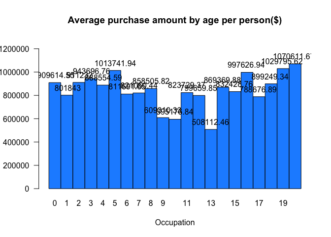

```r
# Visualize the avg_Occupation_spending_per_person
barplot(height = avg_Occupation_spending_per_person$Average, space=0.01, las = 1, main = "Average purchase amount by age per person($)", xlab = "Occupation", ylim = c(0, 1.2*max(avg_Occupation_spending_per_person$Average, na.rm = TRUE)), col = "dodgerblue", names.arg  = avg_Occupation_spending_per_person$Occupation)

space_val = 0
text(x = -0.4 + 1:length(avg_Occupation_spending_per_person$Occupation) * (1+space_val), y = avg_Occupation_spending_per_person$Average, labels = round(avg_Occupation_spending_per_person$Average,2), pos = 3)
```

**The average spending amount of each transaction**

```r
avg_Occupation_spending_per_transaction = data %>%
  select(User_ID, Occupation, Purchase) %>%
  group_by(Occupation) %>%
  summarize(Total_purchase = sum(as.numeric(Purchase)),
            Count = n(),
            Average = Total_purchase/Count)

avg_Occupation_spending_per_transaction
```

```
## # A tibble: 21 x 4
##    Occupation Total_purchase Count Average
##    <fct>               <dbl> <int>   <dbl>
##  1 0               625814811 68120   9187.
##  2 1               414552829 45971   9018.
##  3 2               233275393 25845   9026.
##  4 3               160428450 17366   9238.
##  5 4               657530393 70862   9279.
##  6 5               112525355 11985   9389.
##  7 6               185065697 19822   9336.
##  8 7               549282744 57806   9502.
##  9 8                14594599  1524   9577.
## 10 9                53619309  6153   8714.
## # … with 11 more rows
```

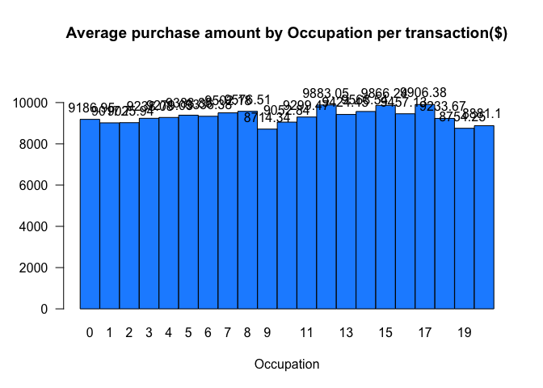

```r
# Visualize the avg_Occupation_spending_per_transaction
barplot(height = avg_Occupation_spending_per_transaction$Average, space=0.01, las = 1, main = "Average purchase amount by Occupation per transaction($)", xlab = "Occupation", ylim = c(0, 1.2*max(avg_Occupation_spending_per_transaction$Average, na.rm = TRUE)), col = "dodgerblue",names.arg  = avg_Occupation_spending_per_transaction$Occupation)

space_val = 0
text(x = -0.4 + 1:length(avg_Occupation_spending_per_transaction$Occupation) * (1+space_val), y = avg_Occupation_spending_per_transaction$Average, labels = round(avg_Occupation_spending_per_transaction$Average,2), pos = 3)
```

It can be seen that the occupational category has a lot to do with the amount of consumption. It can provide products that are more in line with professional characteristics according to the top ranked occupations.

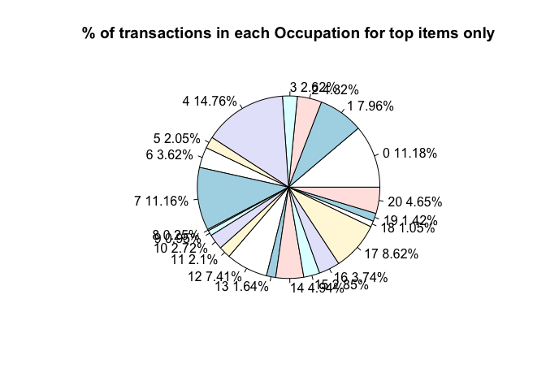

```r
Occupation_transaction_Top_item = data[data$Product_ID %in% top_5$Product_ID,] %>%
  select(User_ID, Occupation) %>%
  group_by(Occupation) %>%
  summarize(Count = n())

# Visualize the Occupation transaction for top items only
pie(Occupation_transaction_Top_item$Count, labels = paste(paste(Occupation_transaction_Top_item$Occupation,round(Occupation_transaction_Top_item$Count/sum(Occupation_transaction_Top_item$Count)*100,2)),"%",sep = ""), main="% of transactions in each Occupation for top items only")
```

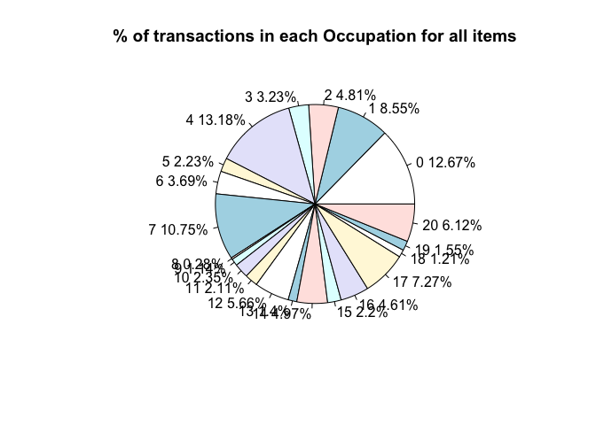

```r
# Visualize the overall Occupation transaction
pie(Occupation_transaction$Count, labels = paste(paste(Occupation_transaction$Occupation,round(Occupation_transaction$Count/sum(Occupation_transaction$Count)*100,2)),"%",sep = ""), main="% of transactions in each Occupation for all items")
```

Comparing these two distribution pie chats, the top 5 products are not related to occupation, which means that there is no any specific occupation that seems to be attracted by these top items obviously.

### Stay_In_Current_City_Years

Lastly, we will take a look at the distribution of customers, in terms of how long they stay in the current city.

```r
Stay_In_Current_City_Years_data = data %>%
  select(User_ID, Stay_In_Current_City_Years) %>%
  group_by(Stay_In_Current_City_Years) %>%
  distinct() %>%
  summarize(Count = n())

Stay_In_Current_City_Years_data
```

```
## # A tibble: 5 x 2
##   Stay_In_Current_City_Years Count
##   <ord>                      <int>
## 1 0                            772
## 2 1                           2086
## 3 2                           1145
## 4 3                            979
## 5 4+                           909
```

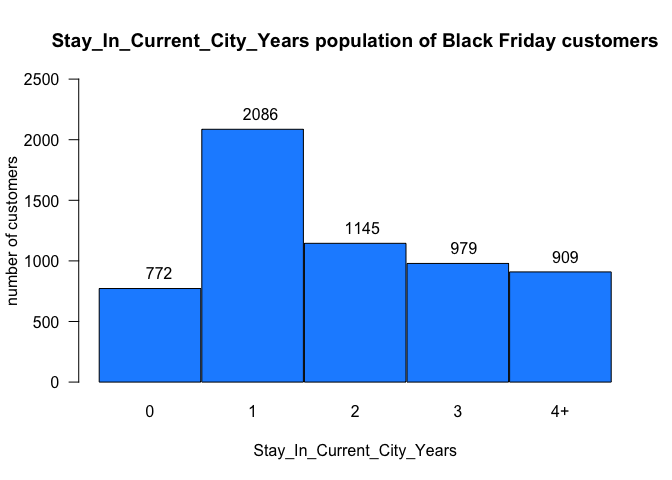

```r
# Visualize the City_Category population
barplot(height = Stay_In_Current_City_Years_data$Count, space=0.01, las = 1, main = "Stay_In_Current_City_Years population of Black Friday customers", ylab = "number of customers", xlab = "Stay_In_Current_City_Years", ylim = c(0, 1.2*max(Stay_In_Current_City_Years_data$Count, na.rm = TRUE)), col = "dodgerblue", names.arg = Stay_In_Current_City_Years_data$Stay_In_Current_City_Years)

space_val = 0
text(x = -0.4 + 1:length(Stay_In_Current_City_Years_data$Stay_In_Current_City_Years) * (1+space_val), y = Stay_In_Current_City_Years_data$Count, labels = Stay_In_Current_City_Years_data$Count, pos = 3)
```

**Interesting fact 9**: People who live for a year consume the most, and then decrement, which makes sense in real life. When you first come to the city, you need to buy all kinds of daily necessities.

# Part3: Cluster Analysis – kmeans

We will provide insight to the black friday sales using clustering with k-means algorithm to inspect the characteristics of each cluster based on (1) needs-based variables, and (2) demographics.

**(1) needs-based**: We select the variables to do with products only.

**pre-process**: In order to use cluster analysis, let’s pre-process the data. Since all the variables to do with purchasing are factor, we need to scale them in the first step.

```r
#Make the categorical dummy variable using dummyVars function in caret
dummy_1 <- dummyVars("~ Product_Category_1 + Product_Category_2 + Product_Category_3", data = data)
new_df_1 <- data.frame(predict(dummy_1, newdata = data))

#Merge the two datasets together
new_data_1 <- cbind(data, new_df_1)

#Select variables that will be used in needs-based clustering:
cluster_data_1 <- new_data_1 %>% select(-User_ID, -Product_ID, -Gender, -Age, -City_Category, -Occupation, -Stay_In_Current_City_Years, -Marital_Status, -Product_Category_1, -Product_Category_2, -Product_Category_3, -Purchase)

#Scale the data
cluster_data_1 <- scale(cluster_data_1)
cluster_data_1[is.na(cluster_data_1)] = 0
```

**Total within sum of squares Plot**

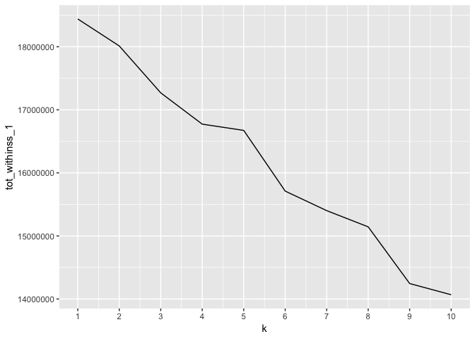

```r
tot_withinss_1 <- map_dbl(1:10,  function(k){
  model <- kmeans(x = cluster_data_1, centers = k)
  model$tot.withinss
})

elbow_df_1 <- data.frame(
  k = 1:10,
  tot_withinss = tot_withinss_1
)

ggplot(elbow_df_1, aes(x = k, y = tot_withinss_1)) +
  geom_line() +
  scale_x_continuous(breaks = 1:10)
```

The “good” value of k is 3 since the “elbow” occur there. We’ll procees with k = 3.

```r
#build a kmeans model
model_km3_1 <- kmeans(cluster_data_1, centers = 3)
#extract the cluster
clust_km3_1 <- model_km3_1$cluster
black_friday_km3_1 <- mutate(as.data.frame(cluster_data_1), cluster = clust_km3_1)
head(black_friday_km3_1)
```

```
##   Product_Category_1.1 Product_Category_1.2 Product_Category_1.3
## 1           -0.5886885            -0.213801            5.1071793
## 2            1.6986880            -0.213801           -0.1958024
## 3           -0.5886885            -0.213801           -0.1958024
## 4           -0.5886885            -0.213801           -0.1958024
## 5           -0.5886885            -0.213801           -0.1958024
## 6            1.6986880            -0.213801           -0.1958024
##   Product_Category_1.4 Product_Category_1.5 Product_Category_1.6
## 1           -0.1482904           -0.6180603           -0.1974101
## 2           -0.1482904           -0.6180603           -0.1974101
## 3           -0.1482904           -0.6180603           -0.1974101
## 4           -0.1482904           -0.6180603           -0.1974101
## 5           -0.1482904           -0.6180603           -0.1974101
## 6           -0.1482904           -0.6180603           -0.1974101
##   Product_Category_1.7 Product_Category_1.8 Product_Category_1.9
```

[output cut: 104 more lines]

```r
#count the number of customer in each cluster:
count(black_friday_km3_1, cluster)
```

```
## # A tibble: 3 x 2
##   cluster      n
##     <int>  <int>
## 1       1  20164
## 2       2 515913
## 3       3   1500
```

```r
#mutate the result back into the original data set
blackfriday_needs_based <- data %>%
                  mutate(cluster = clust_km3_1)
head(blackfriday_needs_based)
```

```
##   User_ID Product_ID Gender   Age Occupation City_Category
## 1 1000001  P00069042      F  0-17         10             A
## 2 1000001  P00248942      F  0-17         10             A
## 3 1000001  P00087842      F  0-17         10             A
## 4 1000001  P00085442      F  0-17         10             A
## 5 1000002  P00285442      M   55+         16             C
## 6 1000003  P00193542      M 26-35         15             A
##   Stay_In_Current_City_Years Marital_Status Product_Category_1
## 1                          2              0                  3
## 2                          2              0                  1
## 3                          2              0                 12
## 4                          2              0                 12
## 5                         4+              0                  8
## 6                          3              0                  1
##   Product_Category_2 Product_Category_3 Purchase cluster
## 1               <NA>               <NA>     8370       2
## 2                  6                 14    15200       2
## 3               <NA>               <NA>     1422       2
## 4                 14               <NA>     1057       2
## 5               <NA>               <NA>     7969       2
## 6                  2               <NA>    15227       2
```

For analyzing the kmeans cluster of all products and purchase, there are 3 clusters showing that the products maily focused on 3 clusters, so based on the clusters, merchants can consider the most cluster variables involved in significant variables such as age, sex and so on (showed as follows)

**Summarize the result**:

1. calculate the mean purchase of each group.

```r
blackfriday_needs_based %>%
  group_by(cluster) %>%
  summarise(mean_purchase = mean(Purchase))
```

```
## # A tibble: 3 x 2
##   cluster mean_purchase
##     <int>         <dbl>
## 1       1        15838.
## 2       2         9069.
## 3       3        13145.
```

Among these three clusters, people in the first cluster purchased the most. When we take more variables into consideration, the results can be used to target customer segments and develop marketing campaign.

2. Use k-means segments to examine distribution of people in these clusters in terms of gender, occupation, and city_Category.

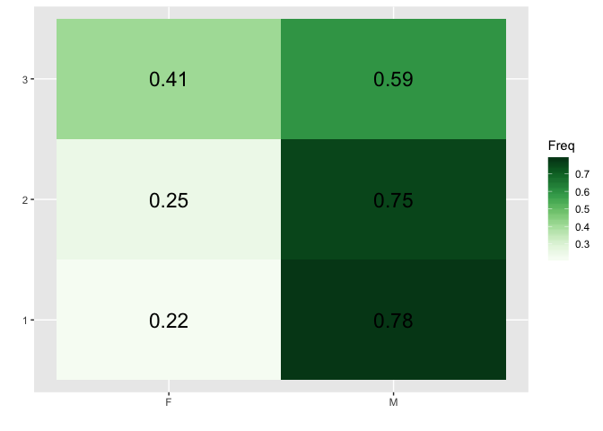

```r
data1 <- cbind(data,clust_km3_1)
library(ggplot2)
library(RColorBrewer)
tab1 = prop.table(table(data1$clust_km3_1,data1[,3]),1)
tab1 = data.frame(round(tab1,2))
ggplot(data=tab1,aes(x=Var2,y=Var1,fill=Freq))+
   geom_tile()+
   geom_text(aes(label=Freq),size=6)+
   xlab(label = '')+
   ylab(label = '')+
   scale_fill_gradientn(colors=brewer.pal(n=9,name = 'Greens'))
```

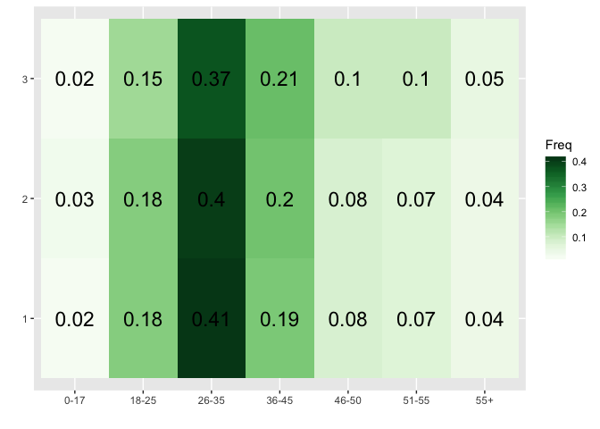

```r
tab2 = prop.table(table(data1$clust_km3_1,data1[,4]),1)
tab2 = data.frame(round(tab2,2))
ggplot(data=tab2,aes(x=Var2,y=Var1,fill=Freq))+
   geom_tile()+
   geom_text(aes(label=Freq),size=6)+
   xlab(label = '')+
   ylab(label = '')+
   scale_fill_gradientn(colors=brewer.pal(n=9,name = 'Greens'))
```

[figure not shown]

```r
tab3 = prop.table(table(data1$clust_km3_1,data1[,5]),1)
tab3 = data.frame(round(tab3,2))
ggplot(data=tab3,aes(x=Var2,y=Var1,fill=Freq))+
   geom_tile()+
   geom_text(aes(label=Freq),size=6)+
   xlab(label = '')+
   ylab(label = '')+
   scale_fill_gradientn(colors=brewer.pal(n=9,name = 'Greens'))
```

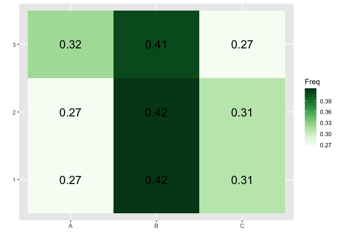

```r
tab4 = prop.table(table(data1$clust_km3_1,data1[,6]),1)
tab4 = data.frame(round(tab4,2))
ggplot(data=tab4,aes(x=Var2,y=Var1,fill=Freq))+
   geom_tile()+
   geom_text(aes(label=Freq),size=6)+
   xlab(label = '')+
   ylab(label = '')+
   scale_fill_gradientn(colors=brewer.pal(n=9,name = 'Greens'))
```

Based on these results, we can find that most people in the first cluster is male and aging between 26 to 35. With these info we target our customer to increase the sale.

**(2) demographic-based**

**pre-process**: In order to use cluster analysis, let pre-process the data. Since all the variables to do with demographic analysis are character, we need to dummy them in the first step and then scale them.

```r
#Make the categorical dummy variable using dummyVars function in caret
dummy_2 <- dummyVars("~ Gender + Age + Occupation + City_Category + Stay_In_Current_City_Years + Marital_Status", data = data)
new_df_2 <- data.frame(predict(dummy_2, newdata = data))

#Merge the two datasets together
new_data_2 <- cbind(data, new_df_2)

#Select variables that will be used in later clustering:
cluster_data_2 <- new_data_2 %>% select(-User_ID, -Product_ID, -Gender, -Age, -City_Category, -Occupation, -Stay_In_Current_City_Years, -Marital_Status, -Product_Category_1, -Product_Category_2, -Product_Category_3, -Purchase)

#Scale the data
cluster_data_2 <- scale(cluster_data_2)
```

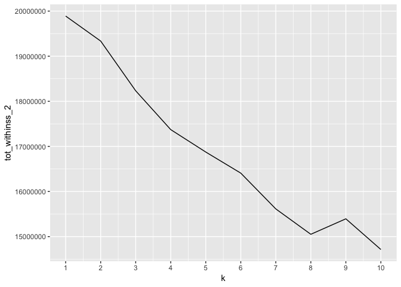

```r
tot_withinss_2 <- map_dbl(1:10,  function(k){
  model <- kmeans(x = cluster_data_2, centers = k)
  model$tot.withinss
})

elbow_df_2 <- data.frame(
  k = 1:10,
  tot_withinss = tot_withinss_2
)

ggplot(elbow_df_2, aes(x = k, y = tot_withinss_2)) +
  geom_line() +
  scale_x_continuous(breaks = 1:10)
```

The “good” value of k is 4 since the “elbow” occur there. We’ll procees with k = 4.

```r
#build a kmeans model
model_km4_2 <- kmeans(cluster_data_2, centers = 4)
#extract the cluster
clust_km4_2 <- model_km4_2$cluster
black_friday_km4_2 <- mutate(as.data.frame(cluster_data_2), cluster = clust_km4_2)
head(black_friday_km4_2)
```

```
##     Gender.F   Gender.M      Age.L      Age.Q      Age.C     Age.4
## 1  1.7511363 -1.7511363 -1.8444373  2.9414283 -1.8483767 0.6347711
## 2  1.7511363 -1.7511363 -1.8444373  2.9414283 -1.8483767 0.6347711
## 3  1.7511363 -1.7511363 -1.8444373  2.9414283 -1.8483767 0.6347711
## 4  1.7511363 -1.7511363 -1.8444373  2.9414283 -1.8483767 0.6347711
## 5 -0.5710567  0.5710567  2.5915185  2.9414283  0.7193369 0.6347711
## 6 -0.5710567  0.5710567 -0.3657853 -0.4614029  0.7193369 0.1940242
##         Age.5       Age.6 Occupation.0 Occupation.1 Occupation.2
## 1  0.03229942 -0.05667292   -0.3809246   -0.3057968   -0.2247329
## 2  0.03229942 -0.05667292   -0.3809246   -0.3057968   -0.2247329
## 3  0.03229942 -0.05667292   -0.3809246   -0.3057968   -0.2247329
## 4  0.03229942 -0.05667292   -0.3809246   -0.3057968   -0.2247329
## 5  0.55074215 -0.05667292   -0.3809246   -0.3057968   -0.2247329
## 6 -1.00458604  0.94743235   -0.3809246   -0.3057968   -0.2247329
##   Occupation.3 Occupation.4 Occupation.5 Occupation.6 Occupation.7
```

[output cut: 48 more lines]

```r
#count the number of customer in each cluster:
count(black_friday_km4_2, cluster)
```

```
## # A tibble: 4 x 2
##   cluster      n
##     <int>  <int>
## 1       1 187946
## 2       2 214141
## 3       3  24790
## 4       4 110700
```

```r
#mutate the result back into the original data set
blackfriday_demographic_based <- data %>%
                  mutate(cluster = clust_km4_2)
head(blackfriday_demographic_based)
```

```
##   User_ID Product_ID Gender   Age Occupation City_Category
## 1 1000001  P00069042      F  0-17         10             A
## 2 1000001  P00248942      F  0-17         10             A
## 3 1000001  P00087842      F  0-17         10             A
## 4 1000001  P00085442      F  0-17         10             A
## 5 1000002  P00285442      M   55+         16             C
## 6 1000003  P00193542      M 26-35         15             A
##   Stay_In_Current_City_Years Marital_Status Product_Category_1
## 1                          2              0                  3
## 2                          2              0                  1
## 3                          2              0                 12
## 4                          2              0                 12
## 5                         4+              0                  8
## 6                          3              0                  1
##   Product_Category_2 Product_Category_3 Purchase cluster
## 1               <NA>               <NA>     8370       4
## 2                  6                 14    15200       4
## 3               <NA>               <NA>     1422       4
## 4                 14               <NA>     1057       4
## 5               <NA>               <NA>     7969       3
## 6                  2               <NA>    15227       2
```

**Summarize the result**:

1. calculate the mean purchase of each group.

```r
blackfriday_demographic_based %>%
  group_by(cluster) %>%
  summarise(mean_purchase = mean(Purchase))
```

```
## # A tibble: 4 x 2
##   cluster mean_purchase
##     <int>         <dbl>
## 1       1         9359.
## 2       2         9363.
## 3       3         9457.
## 4       4         9207.
```

When we take more variables into consideration, the results can be used to target customer segments and develop marketing campaign.

2. Use k-means segments to examine means of each demographic-based variable.

```r
data2 <- cbind(data,clust_km4_2)
prop.table(table(data2$clust_km4_2,data2[,3]),1)
```

```
##
##             F         M
##   1 0.2488321 0.7511679
##   2 0.2453944 0.7546056
##   3 0.1611940 0.8388060
##   4 0.2609304 0.7390696
```